# D_call_final_report

Peter Xiong

2025-06-07

## Introduction

Blue-whale D-calls, commonly associated with foraging behaviour, offer a window into how these large predators exploit prey patches within the Southern California Bight. Building on earlier work that emphasised modelling each call type separately to untangle behavioural ecology, this report develops a **spatiotemporal species-distribution model** for D-call acoustic presence. We merged 2009-2023 CalCOFI acoustic detections with CASE-STSE environmental grids, standardising temperature, salinity, current magnitude (speed) and direction (theta) at multiple depths, and appending geolocation (lat / lon) and seasonal indices. After exploratory visualisations to gauge zero-inflation and covariate patterns, we trained a delta-gamma mixed model (`sdmTMB`) that simultaneously handles presence/absence (logit link) and positive call intensity (log link). Spatial structure was captured with an SPDE mesh (cut-off = 10 km) while season acted as the temporal random effect. The report walks through (1) data cleaning and exploratory analysis, (2) model fitting and diagnostics, (3) predictive performance, and (4) heat-map visualisations highlighting hotspots in the most recent survey year.

## Load Packages and Data

```r
# Load in the libraries
library(tidyverse)
library(sdmTMB)
library(ggplot2)
library(janitor)
library(sp)
library(readr)
library(ggcorrplot)
library(Metrics)
library(naniar)
library(tibble)
library(rsample)
library(caret)
library(purrr)
library(tune)
library(ggExtra)
library(gridExtra)

# Libraries for plotting
library(sf)
library(rnaturalearth)
library(viridis)
library(patchwork)
```

```r
# Read in the data
cal_data <- read.csv("D:/Desktop/PSTAT197B/scripps/capstone-scripps/data/Merged_CalCOFI/merged_std_data_05_13_25.csv")
```

## Data Cleaning

```r
# Removing the first two columns
cal_data <- cal_data[, -c(1, 2)]

# Changing dataset to only have present response data
cal_data <- cal_data %>%
  filter(!is.na(d_scaled)) %>%
  mutate(blue_resp = a_scaled + b_scaled + d_scaled)
```

## Exploratory Data Analysis

### Response vs Predictors

Before modeling, I want to explore the relationship between the response variable and predictors.

First, we need to filter out all zero values:

```r
d_filtered <- cal_data %>% filter(d_scaled!= 0)
```

#### D calls vs. Lon&Lat

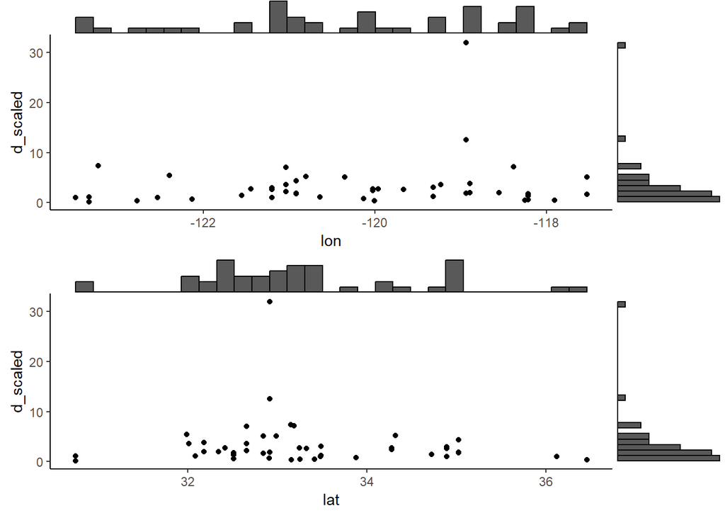

```r
p1 <- ggplot(d_filtered, aes(x = lon, y = d_scaled)) +
  geom_point() +
  theme_classic()

p1_marginal <- ggMarginal(p1, type = "histogram")

p2 <- ggplot(d_filtered, aes(x = lat, y = d_scaled)) +
  geom_point() +
  theme_classic()

p2_marginal <- ggMarginal(p2, type = "histogram")

## Arrange them in a single row
gridExtra::grid.arrange(p1_marginal, p2_marginal)
```

#### D calls vs. Season

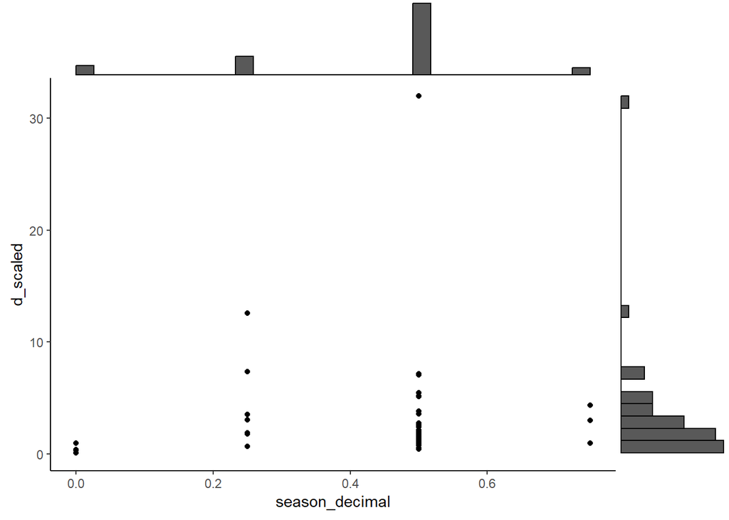

```r
p3 <- ggplot(d_filtered, aes(x = season_decimal, y = d_scaled)) +
  geom_point() +
  theme_classic()

ggMarginal(p3, type = "histogram")
```

From the plot, we can see that most D calls were detected in spring and summer. It means that blue whales are more active in spring and summer.

#### D calls vs. Temperature

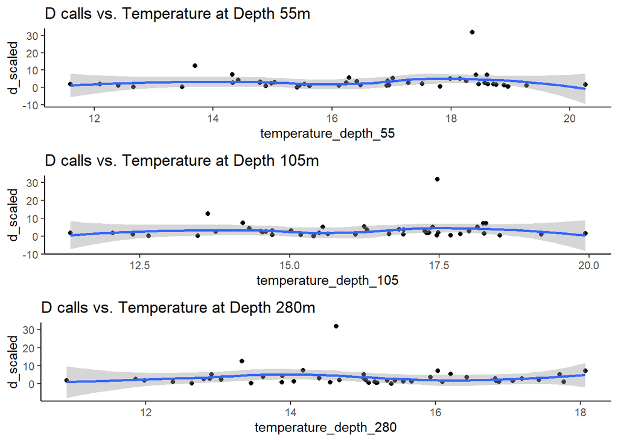

```r
p4 <- ggplot(d_filtered, aes(x = temperature_depth_55, y = d_scaled)) +
  geom_point() +
  geom_smooth(method = "loess") +
  labs(title = "D calls vs. Temperature at Depth 55m")+
  theme_classic()

p5 <- ggplot(d_filtered, aes(x = temperature_depth_105, y = d_scaled)) +
  geom_point() +
  geom_smooth(method = "loess") +
  labs(title = "D calls vs. Temperature at Depth 105m")+
  theme_classic()

p6 <- ggplot(d_filtered, aes(x = temperature_depth_280, y = d_scaled)) +
  geom_point() +
  geom_smooth(method = "loess") +
  labs(title = "D calls vs. Temperature at Depth 280m")+
  theme_classic()

## Arrange them in a single row
gridExtra::grid.arrange(p4, p5, p6)
```

#### D calls vs. Pressure

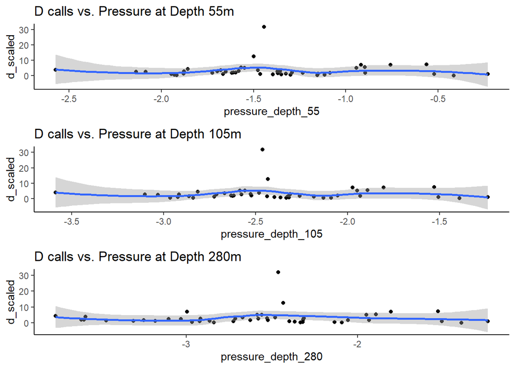

```r
p7 <- ggplot(d_filtered, aes(x = pressure_depth_55, y = d_scaled)) +
  geom_point() +
  geom_smooth(method = "loess") +
  labs(title = "D calls vs. Pressure at Depth 55m")+
  theme_classic()

p8 <- ggplot(d_filtered, aes(x = pressure_depth_105, y = d_scaled)) +
  geom_point() +
  geom_smooth(method = "loess") +
  labs(title = "D calls vs. Pressure at Depth 105m")+
  theme_classic()

p9 <- ggplot(d_filtered, aes(x = pressure_depth_280, y = d_scaled)) +
  geom_point() +
  geom_smooth(method = "loess") +
  labs(title = "D calls vs. Pressure at Depth 280m")+
  theme_classic()

## Arrange them in a single row
gridExtra::grid.arrange(p7, p8, p9)
```

Across the 55 m, 105 m, and 280 m layers, the smoothed blue curves remain essentially flat, with confidence bands overlapping zero throughout the observed pressure range. Scattered points—including a few high-count outliers—occur at various pressure values without a clear pattern. The similarity of the three panels reinforces that depth-specific pressure offers little additional information for explaining D-call intensity. In short, ambient pressure shows no meaningful relationship with blue-whale D-call activity in this data set.

#### D calls vs. Salinity

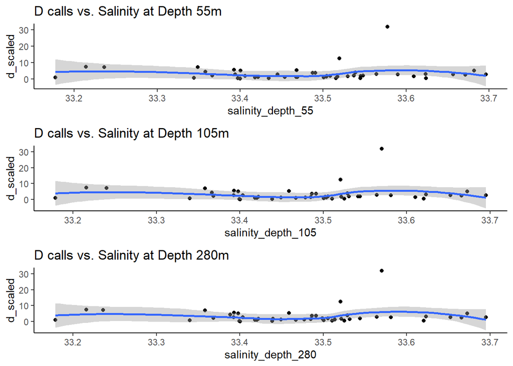

```r
s1 <- ggplot(d_filtered, aes(x = salinity_depth_55, y = d_scaled)) +
  geom_point() +
  geom_smooth(method = "loess") +
  labs(title = "D calls vs. Salinity at Depth 55m")+
  theme_classic()

s2 <- ggplot(d_filtered, aes(x = salinity_depth_105, y = d_scaled)) +
  geom_point() +
  geom_smooth(method = "loess") +
  labs(title = "D calls vs. Salinity at Depth 105m")+
  theme_classic()

s3 <- ggplot(d_filtered, aes(x = salinity_depth_280, y = d_scaled)) +
  geom_point() +
  geom_smooth(method = "loess") +
  labs(title = "D calls vs. Salinity at Depth 280m")+
  theme_classic()

## Arrange them in a single row
gridExtra::grid.arrange(s1, s2, s3)
```

For salinity values ranging ≈ 33.2–33.7 PSU, the smoothed trend lines at 55 m, 105 m, and 280 m are virtually flat, with confidence bands overlapping zero along the entire axis. Most D-call counts remain below 5, and the few larger outliers appear at assorted salinities. Because all three depths yield the same, near-zero slope, salinity—like temperature and pressure—shows no discernible influence on D-call intensity in this dataset, and separate depth layers add no extra explanatory power.

#### D calls vs. Magnitude

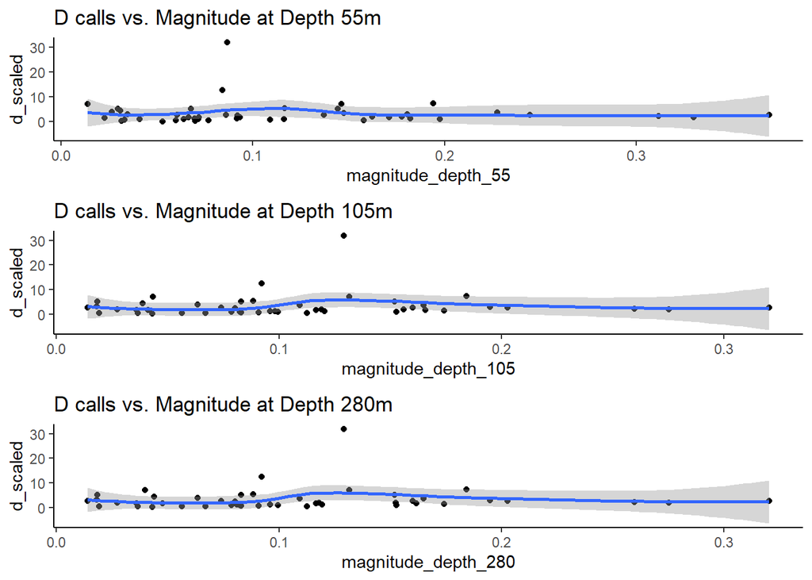

```r
m1 <- ggplot(d_filtered, aes(x = magnitude_depth_55, y = d_scaled)) +
  geom_point() +
  geom_smooth(method = "loess") +
  labs(title = "D calls vs. Magnitude at Depth 55m")+
  theme_classic()

m2 <- ggplot(d_filtered, aes(x = magnitude_depth_105, y = d_scaled)) +
  geom_point() +
  geom_smooth(method = "loess") +
  labs(title = "D calls vs. Magnitude at Depth 105m")+
  theme_classic()

m3 <- ggplot(d_filtered, aes(x = magnitude_depth_280, y = d_scaled)) +
  geom_point() +
  geom_smooth(method = "loess") +
  labs(title = "D calls vs. Magnitude at Depth 280m")+
  theme_classic()

## Arrange them in a single row
gridExtra::grid.arrange(m1, m2, m3)
```

Current magnitude (0–0.35 m s⁻¹) shows virtually no association with D-call intensity at 55 m, 105 m, or 280 m. Smoothed lines are flat and confidence bands straddle zero throughout, while most detections remain under 5 regardless of flow speed. A few high outliers appear but do not cluster at any particular magnitude. Thus, current speed—like the other environmental variables examined—adds little explanatory power for predicting D-call counts, and additional depth layers do not change that conclusion.

#### D calls vs. Theta

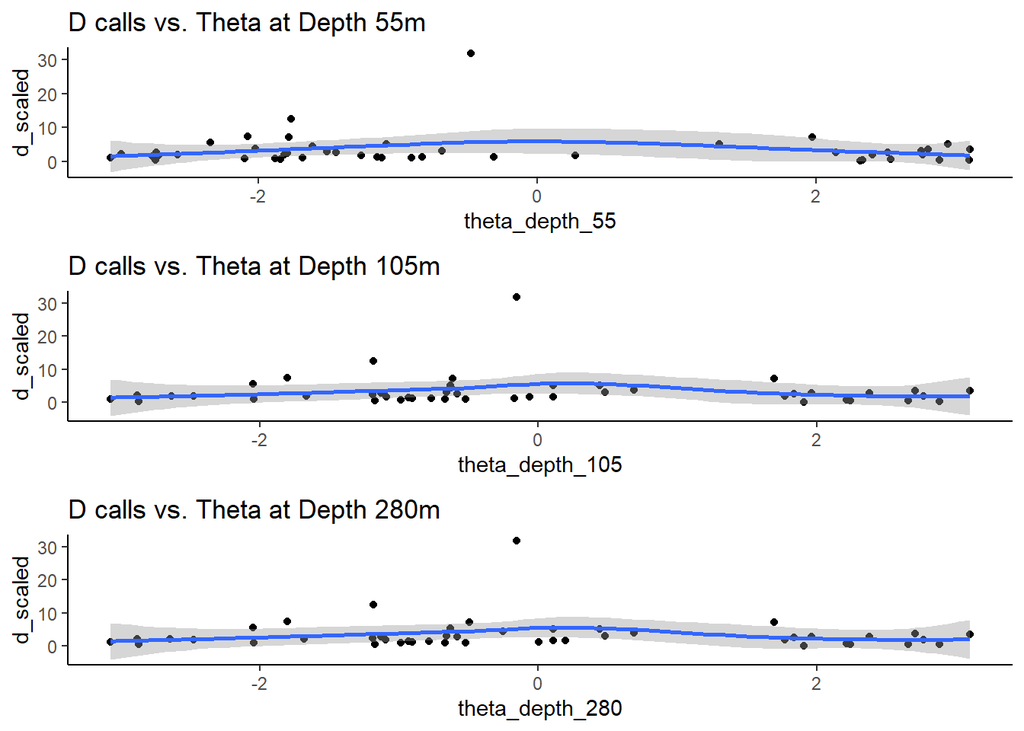

```r
t1 <- ggplot(d_filtered, aes(x = theta_depth_55, y = d_scaled)) +
  geom_point() +
  geom_smooth(method = "loess") +
  labs(title = "D calls vs. Theta at Depth 55m")+
  theme_classic()

t2 <- ggplot(d_filtered, aes(x = theta_depth_105, y = d_scaled)) +
  geom_point() +
  geom_smooth(method = "loess") +
  labs(title = "D calls vs. Theta at Depth 105m")+
  theme_classic()

t3 <- ggplot(d_filtered, aes(x = theta_depth_280, y = d_scaled)) +
  geom_point() +
  geom_smooth(method = "loess") +
  labs(title = "D calls vs. Theta at Depth 280m")+
  theme_classic()

## Arrange them in a single row
gridExtra::grid.arrange(t1, t2, t3)
```

The direction of flow (θ, scaled between –π and +π) shows the same story at 55 m, 105 m, and 280 m: the fitted trend is essentially flat with confidence bands that straddle zero across all directions. Most detections cluster near zero counts, and the handful of large outliers are scattered at various θ values rather than concentrated in any quadrant. Because the three depth profiles are nearly identical, current direction provides little independent information for predicting D-call intensity, confirming that directional flow is not a key driver in this dataset.

### Correlation Plot

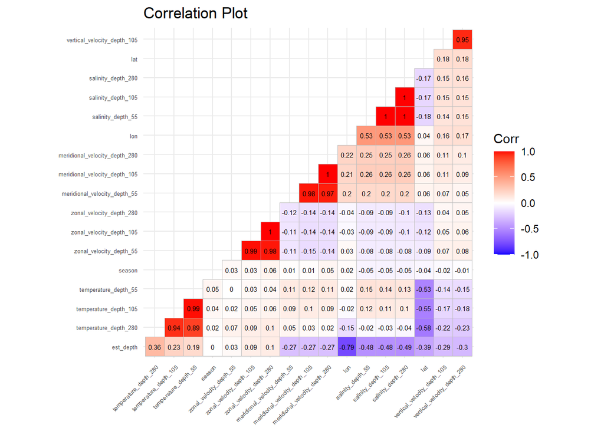

```r
# Plotting Correlation
# Define expected columns
cols_to_use <- c("est_depth",
                 "temperature_depth_105", "temperature_depth_280", "temperature_depth_55",
                 "salinity_depth_105", "salinity_depth_280", "salinity_depth_55",
                 "meridional_velocity_depth_105", "meridional_velocity_depth_280", "meridional_velocity_depth_55",
                 "zonal_velocity_depth_105", "zonal_velocity_depth_280", "zonal_velocity_depth_55",
                 "vertical_velocity_depth_105", "vertical_velocity_depth_280", "vertical_velocity_55", "larvae_count", "lon", "lat", "season")

# Keep only existing columns
existing_cols <- intersect(cols_to_use, colnames(cal_data))
cor_data <- cal_data[, existing_cols, drop = FALSE]

# Compute correlation matrix (use complete.obs to skip missing data)
cor_matrix <- cor(cor_data, use = "complete.obs")

# Correlation plot
ggcorrplot(cor_matrix,
           lab = TRUE,
           hc.order = TRUE,
           lab_size =2,
           tl.cex = 5,
           type = "lower",
           title = "Correlation Plot")
```

For modelling, this means that including multiple depths of a highly correlated variable will add redundancy and inflates multicollinearity, potentially causing singular fits or unstable coefficients. A practical remedy is to keep just one representative depth per variable (or combine depths through PCA/regularisation), while retaining spatial terms that contribute largely independent information.

### Missing Data

We need to make sure that there is no missing data.

```r
# Count how many missing values there are
sum(is.na(cal_data))
```

```
## [1] 0
```

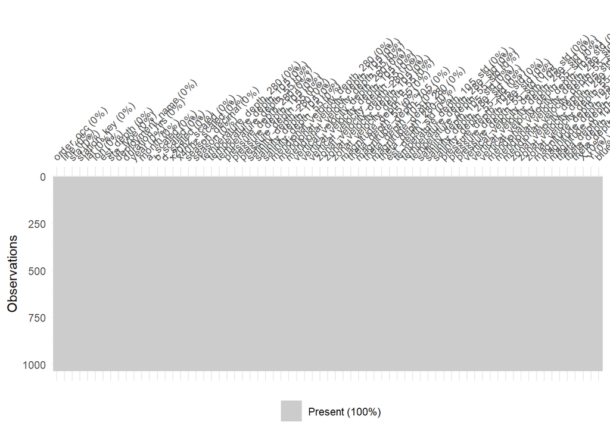

```r
# Visualize missing data
missing_data_plot <- naniar::vis_miss(cal_data)
print(missing_data_plot)
```

## Splitting the Data

```r
# Split data into training and testing sets with most recent year as our testing set
set.seed(123)
last_year <- max(cal_data$year)
train_data <- cal_data %>% filter(year != last_year)
test_data <- cal_data %>% filter(year == last_year)
```

## Prediction Plot

#### Function

To determine the performance of models, we want to make a prediction plot to compare the predicted whale existence with the real one. Thus, we need to write a function for plotting.

```r
generate_seasonal_prediction_plots <- function(fit, year, test_data, cap, resp) {

  plots <- list()
  coast <- rnaturalearth::ne_coastline(scale = "medium", returnclass = "sf")
  choose_folder <- function(variable, year) {
    base_path <- "D:/Desktop/PSTAT197B/scripps/capstone-scripps/data/Specificdate"
    if (variable == "temperature") {
      return(file.path(base_path, "Temperature", "temperature_avg_output"))
    }
    if (variable == "salinity") {
      return(file.path(base_path, "Salinity", "salinity_avg_output"))
    }
    if (variable == "pressure") {
      return(file.path(base_path, "Pressure", "pressure_avg_output"))
    }
    if (variable == "mvel") {
      return(file.path(base_path, "Meridional_velocity", "meridional_velocity_avg_output"))
    }
    if (variable == "zvel") {
      return(file.path(base_path, "Zonal_velocity", "zonal_velocity_avg_output"))
    }
  }

  pivot_grid <- function(df, var_name) {
    df %>%
      rename(lon = 1) %>%
      pivot_longer(cols = starts_with("Lat_"), names_to = "lat", values_to = var_name) %>%
      mutate(
        lat = as.numeric(str_remove(lat, "Lat_")),
        lon = as.numeric(str_remove(lon, "Lon_")) - 360,
        !!var_name := if (!str_detect(var_name, "meridional_velocity|zonal_velocity"))
          scale(.data[[var_name]])[, 1] else .data[[var_name]]
      )
  }

  get_season <- function(month) {
    case_when(
      month %in% c(12, 1, 2) ~ 0,
      month %in% 3:5 ~ 0.25,
      month %in% 6:8 ~ 0.5,
      month %in% 9:11 ~ 0.75
    )
  }

  for (season_val in c(0, 0.25, 0.5, 0.75)) {
    # issue in that the 12 is 12 of that year -> need to hardcode 12 of previous year
    season_months <- list(`0` = c(12, 1, 2), `0.25` = 3:5, `0.5` = 6:8, `0.75` = 9:11)[[as.character(season_val)]]
    season_data <- list()

    for (month in season_months) {
      date <- sprintf("%s-%02d", year, month)
      combined <- NULL
      for (depth in c("-55.0", "-105.0", "-280.0")) {
        added <- paste0("avg_depth_", depth, "_month_", date, ".csv")
        temp_path <- file.path(choose_folder("temperature", year), paste0("temperature_", added))
        sal_path  <- file.path(choose_folder("salinity", year), paste0("salinity_", added))
        pres_path <- file.path(choose_folder("pressure", year), paste0("pressure_", added))
        mvel_path <- file.path(choose_folder("mvel", year), paste0("meridional_velocity_", added))
        zvel_path <- file.path(choose_folder("zvel", year), paste0("zonal_velocity_", added))

        if (!file.exists(temp_path) || !file.exists(sal_path) || !file.exists(pres_path)) next

        depth_clean <- str_remove_all(depth, "[-]|\\.0$")
        temp_var <- paste0("temperature_depth_", depth_clean, "_std")
        sal_var  <- paste0("salinity_depth_", depth_clean, "_std")
        pres_var <- paste0("pressure_depth_", depth_clean, "_std")
        mvel_var <- paste0("meridional_velocity_depth_", depth_clean, "_std")
        zvel_var <- paste0("zonal_velocity_depth_", depth_clean, "_std")

        temp_long <- pivot_grid(read_csv(temp_path, show_col_types = FALSE), temp_var)
        sal_long  <- pivot_grid(read_csv(sal_path, show_col_types = FALSE),  sal_var)
        pres_long <- pivot_grid(read_csv(pres_path, show_col_types = FALSE), pres_var)
        mvel_long <- pivot_grid(read_csv(mvel_path, show_col_types = FALSE), mvel_var)
        zvel_long <- pivot_grid(read_csv(zvel_path, show_col_types = FALSE), zvel_var)

        depth_df <- temp_long %>%
          left_join(sal_long, by = c("lat", "lon")) %>%
          left_join(pres_long, by = c("lat", "lon")) %>%
          left_join(mvel_long, by = c("lat", "lon")) %>%
          left_join(zvel_long, by = c("lat", "lon"))

        combined <- if (is.null(combined)) depth_df else left_join(combined, depth_df, by = c("lat", "lon"))
      }
      for (depth in c("55", "105", "280")) {
        z_col <- paste0("zonal_velocity_depth_", depth, "_std")
        m_col <- paste0("meridional_velocity_depth_", depth, "_std")
        mag_col <- paste0("magnitude_depth_", depth, "_std")
        theta_col <- paste0("theta_depth_", depth, "_std")
        combined[[mag_col]] <- sqrt(combined[[z_col]]^2 + combined[[m_col]]^2)
        combined[[theta_col]] <- atan2(combined[[z_col]], combined[[m_col]])
      }
      for (depth in c("55", "105", "280")) {
        for (suffix in c("magnitude", "theta")) {
          col <- paste0(suffix, "_depth_", depth, "_std")
          combined[[col]] <- scale(combined[[col]])[, 1]
        }
      }
      combined <- combined %>% add_utm_columns(ll_names = c("lon", "lat")) %>% drop_na()
      season_data[[length(season_data) + 1]] <- combined
    }



    if (length(season_data) == 0) next

    combined_season <- bind_rows(season_data) %>%
      group_by(lon, lat) %>%
      summarise(across(everything(), mean, na.rm = TRUE), .groups = "drop") %>%
      mutate(season = as.numeric(year) + season_val)
    pred <- predict(fit, newdata = combined_season, type = "response")
    pred$lon <- combined_season$lon
    pred$lat <- combined_season$lat
    observed <- test_data %>%
      filter(season == as.numeric(year) + season_val, !is.na(resp), resp > 0) %>%
      select(lon, lat, resp)

    # Define bounding box from prediction
    lon_min <- min(pred$lon, na.rm = TRUE)
    lon_max <- max(pred$lon, na.rm = TRUE)
    lat_min <- min(pred$lat, na.rm = TRUE)
    lat_max <- max(pred$lat, na.rm = TRUE)

    # Crop coastline to match prediction extent
    coast_crop <- sf::st_crop(coast, xmin = lon_min, xmax = lon_max,
                                  ymin = lat_min, ymax = lat_max)
    season_label <- c("Winter", "Spring", "Summer", "Fall")[[which(c(0, 0.25, 0.5, 0.75) == season_val)]]

    p <- ggplot(pred, aes(x = lon, y = lat)) +
    geom_tile(aes(fill = est)) +
    geom_sf(data = coast_crop, inherit.aes = FALSE, color = "black", fill = NA, size = 0.3) +
    coord_sf(xlim = c(lon_min, lon_max), ylim = c(lat_min, lat_max), expand = FALSE) +
    scale_x_continuous(name = "Longitude", labels = scales::number_format(accuracy = 1)) +
    scale_y_continuous(name = "Latitude", labels = scales::number_format(accuracy = 1)) +
    scale_fill_viridis_c(
      name = "Predicted",
      limits = if (cap > 0) c(0, cap) else NULL,
      oob = scales::squish
    ) +
    labs(
      title = paste(season_label, year)
    ) +
    theme_minimal() +
    theme(
      legend.background = element_rect(fill = "transparent", color = NA),
      legend.box.background = element_rect(fill = "transparent", color = NA),
      legend.key = element_rect(fill = "transparent", color = NA),
      panel.background = element_rect(fill = "transparent", color = NA)
    )


    # Add observed detections and non-detections
    if (nrow(observed) > 0) {
      observed <- observed %>%
        filter(lon >= lon_min, lon <= lon_max, lat >= lat_min, lat <= lat_max)

      observed[[resp]] <- as.numeric(as.character(observed[[resp]]))
      detected <- observed %>% filter(.data[[resp]] > 0)
      nondetected <- observed %>% filter(.data[[resp]] == 0)

      # Add detections (sized red points)
      if (nrow(detected) > 0) {
        p <- p +
          geom_point(
            data = detected,
            aes(x = lon, y = lat, size = .data[[resp]]),
            color = "red", shape = 21, stroke = 0.5, fill = "red"
          )
      }

      # Add non-detections (small blue dots)
      if (nrow(nondetected) > 0) {
        p <- p +
          geom_point(
            data = nondetected,
            aes(x = lon, y = lat),
            color = "lightblue", size = 0.5, shape = 21, stroke = 0.3, fill = "lightblue"
          )
      }
    max_obs <- max(test_data[[resp]], na.rm = TRUE)
    p <- p + scale_size_continuous(
      name = "Observed",
      range = c(1, 3),  # dot sizes (not legend) still start from 1
      limits = c(1, max_obs),  # includes 0 for completeness
      breaks = pretty(c(1, max_obs), n = 4)  # legend starts at 1
    )
  }

    plots[[season_label]] <- p
  }
  return(plots)
}
```

## The best model

```r
# Create mesh using training data
mesh_train <- make_mesh(train_data,
                        xy_cols = c("X", "Y"),
                        cutoff = 10)

# Fit spatiotemporal model
fit_spatiotemporal <- sdmTMB(
  d_scaled ~ lat + lon + temperature_depth_55_std + salinity_depth_55_std + magnitude_depth_55_std + theta_depth_55_std,
  data = train_data,
  mesh = mesh_train,
  time = "season",
  family = delta_gamma(link1 = "logit", link2 = "log"),
  spatial = "on",
  spatiotemporal = "iid",
  extra_time = unique(test_data$season)
)
# Extract coefficients and sanity check
#tidy(fit_spatiotemporal, conf.int = TRUE)
sanity(fit_spatiotemporal)
```

```
## ✔ Non-linear minimizer suggests successful convergence
```

```
## ✔ Hessian matrix is positive definite
```

```
## ✔ No extreme or very small eigenvalues detected
```

```
## ✖ `b_j` gradient > 0.001
```

```
## ℹ See ?run_extra_optimization(), standardize covariates, and/or simplify the model
```

```
## ✖ `b_j` gradient > 0.001
## ℹ See ?run_extra_optimization(), standardize covariates, and/or simplify the model
```

```
## ✔ No fixed-effect standard errors are NA
```

```
## ✖ `ln_tau_O` standard error may be large
```

```
## ℹ `ln_tau_O` is an internal parameter affecting `sigma_O`
```

```
## ℹ `sigma_O` is the spatial standard deviation
```

```
## ℹ Try simplifying the model, adjusting the mesh, or adding priors
```

```
## ✖ `ln_tau_E` standard error may be large
```

```
## ℹ `ln_tau_E` is an internal parameter affecting `sigma_E`
```

```
## ℹ `sigma_E` is the spatiotemporal standard deviation
```

```
## ℹ Try simplifying the model, adjusting the mesh, or adding priors
```

```
## ✖ `ln_kappa` standard error may be large
```

```
## ℹ `ln_kappa` is an internal parameter affecting `range`
```

```
## ℹ `range` is the distance at which data are effectively independent
```

```
## ℹ Try simplifying the model, adjusting the mesh, or adding priors
```

```
## ✖ `sigma_E` is smaller than 0.01
```

```
## ℹ Consider omitting this part of the model
```

```
## ✔ Range parameters don't look unreasonably large
```

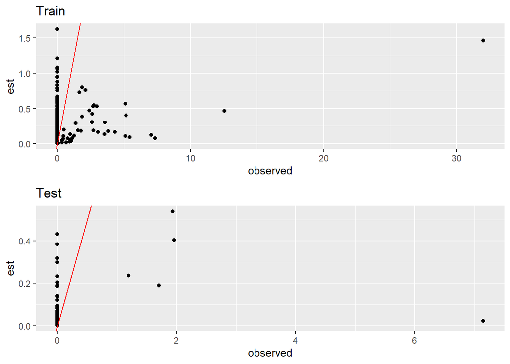

```r
# Predictions on training and test data
training_pred <- predict(fit_spatiotemporal, newdata = train_data, type = "response")
training_pred$observed <- train_data$d_scaled

test_pred <- predict(fit_spatiotemporal, newdata = test_data, type = "response")
test_pred$observed <- test_data$d_scaled

# Plotting the predictions
p0 <- ggplot(training_pred, aes(x = observed, y = est)) +
  geom_point() +
  ggtitle("Train") +
  geom_abline(intercept = 0, slope = 1, col = "red")

p1 <- ggplot(test_pred, aes(x = observed, y = est)) +
  geom_point() +
  ggtitle("Test") +
  geom_abline(intercept = 0, slope = 1, col = "red")

gridExtra::grid.arrange(p0, p1)
```

```r
# Compute RMSE
rmse_train <- rmse(training_pred$observed, training_pred$est)
rmse_test <- rmse(test_pred$observed, test_pred$est)

# Compute Range
range_train <- range(train_data$d_scaled, na.rm = TRUE)
range_test <- range(test_data$d_scaled, na.rm = TRUE)

# Compute Standard Deviation
sd_train <- sd(train_data$d_scaled, na.rm = TRUE)
sd_test <- sd(test_data$d_scaled, na.rm = TRUE)

# Assemble the table
summary_table <- data.frame(
  Dataset = c("Training", "Test"),
  RMSE = c(rmse_train, rmse_test),
  Range_Min = c(range_train[1], range_test[1]),
  Range_Max = c(range_train[2], range_test[2]),
  Std_Dev = c(sd_train, sd_test)
)

# Print the summary table
print(summary_table)
```

```
##    Dataset      RMSE Range_Min Range_Max   Std_Dev
## 1 Training 1.2531253         0 31.976570 1.2961276
## 2     Test 0.6775498         0  7.145901 0.6932196
```

```r
d_plots <- generate_seasonal_prediction_plots(fit_spatiotemporal, year = "2023", test_data = test_data, cap = 0.5, resp = "d_scaled")
```

[output not shown]

[output not shown]

[output not shown]

[output not shown]

[output not shown]

[output not shown]

[output not shown]

[output not shown]

[output not shown]

[output not shown]

[output not shown]

[output not shown]

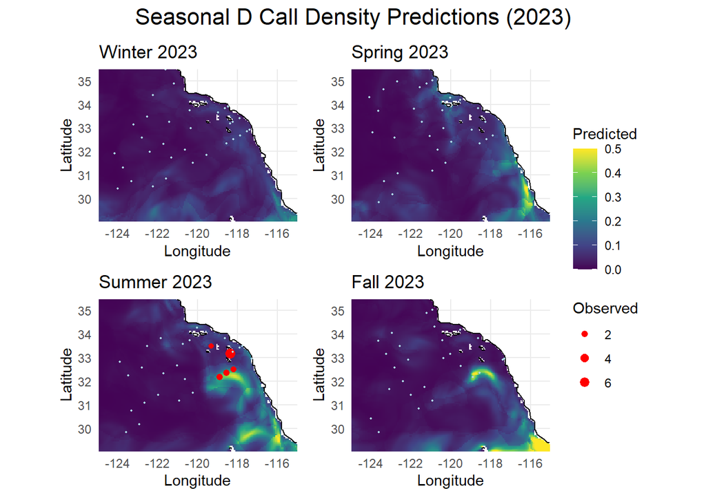

```r
wrap_d_plots <- wrap_plots(d_plots, ncol = 2, nrow = 2, guides = "collect") +
  plot_annotation(
    title = "Seasonal D Call Density Predictions (2023)",
    theme = theme(plot.title = element_text(hjust = 0.5, size = 16))
  )
print(wrap_d_plots)
```

## Conclusion

Ecologically, our findings indicate that coarse-resolution hydrographic fields alone do not explain the patchiness of blue-whale foraging calls; finer-scale proxies for prey (e.g., zooplankton biomass), bathymetric complexity, or dynamic features such as fronts and eddies may be necessary. Future work should experiment with hierarchical hurdle models that incorporate prey layers, test alternative temporal resolutions (monthly vs. seasonal), and extend the framework to simultaneous multi-call models to compare behavioural niches directly. Despite these limitations, the generated prediction maps provide a first spatially-explicit baseline for D-call activity and can guide targeted acoustic monitoring or ecosystem management in the region.